# 20241020_Exercise #3 Heatmaps

Ghipsel Cibrian

2024-10-20

# ORLA 6541

Cindy Do, Faris Makarim, Ghipsel Cibrian

3. Provide a 2-3 page single spaced brief research proposal in which you argue for and justify the use of cluster analysis heatmap in a research topic that you are interested in. Please address the following questions in this order as you apply your new knowledge of cluster analysis and heatmaps (feel free to write this part in MS Word or similar and copy/paste into the markdown).

What is the purpose of your study? Is there any research literature and theory that supports this argument? How so? Why is cluster analysis heatmaps a means to address this purpose? What would be the research question(s)? (To what extent…) What type of dataset would you need? Is there a dataset you know of that would work? What types of data would you be looking for? Provide the generalized equation for the clustering and a brief narrative in which you specify the type of clustering, following the examples from the readings. What do you think you would find? Why would this be important? What would be the implications for this research domain? Optional Stretch Goal:

Completion or not of this optional stretch goal will have no effect team member grades.

Use the TidyTuesday data from September of 2021 on the Billboard Top 100 songs chart from Spotify:

https://github.com/rfordatascience/tidytuesday/blob/master/data/2021/2021-09-14/readme.mdLinks to an external site.

Focusing on describing the data by song, select songs based on:

spotify_track_popularity > 90.

Then replicate as many of the aspects of the below cluster analysis heatmap as you can, which may include among other aspects:

Row order Column order Annotations Font size Labels Provide a few sentences within your markdown on the successes and challenges in working to replicate as many aspects of the visualization as you can.

### 1. mtrcars Heatmaps

```r
library(ComplexHeatmap)
library(circlize)
library(hopach)
#van der Laan MJ, Pollard KS (2003). “Hybrid clustering of gene expression data with visualization and the bootstrap.” Journal of Statistical Planning and Infererence, 117, 275-303.
#https://www.bioconductor.org/packages/release/bioc/html/hopach.html
```

Read data from “mtcars” dataset

```r
head(mtcars)
```

```
##                    mpg cyl disp  hp drat    wt  qsec vs am gear carb
## Mazda RX4         21.0   6  160 110 3.90 2.620 16.46  0  1    4    4
## Mazda RX4 Wag     21.0   6  160 110 3.90 2.875 17.02  0  1    4    4
## Datsun 710        22.8   4  108  93 3.85 2.320 18.61  1  1    4    1
## Hornet 4 Drive    21.4   6  258 110 3.08 3.215 19.44  1  0    3    1
## Hornet Sportabout 18.7   8  360 175 3.15 3.440 17.02  0  0    3    2
## Valiant           18.1   6  225 105 2.76 3.460 20.22  1  0    3    1
```

For this project, we will first use the first seven continuous variables in the dataset, and reserve variable 8 and 9 for dichotomous (0/1) annotations in a future step.

```r
#numeric variables
data<-mtcars[, c(1:7)]

head(data)
```

```
##                    mpg cyl disp  hp drat    wt  qsec
## Mazda RX4         21.0   6  160 110 3.90 2.620 16.46
## Mazda RX4 Wag     21.0   6  160 110 3.90 2.875 17.02
## Datsun 710        22.8   4  108  93 3.85 2.320 18.61
## Hornet 4 Drive    21.4   6  258 110 3.08 3.215 19.44
## Hornet Sportabout 18.7   8  360 175 3.15 3.440 17.02
## Valiant           18.1   6  225 105 2.76 3.460 20.22
```

Rescale data so that continous variables are on the same scales

```r
data.scale<-scale(data)
head(data.scale)
```

```
##                          mpg        cyl        disp         hp       drat
## Mazda RX4          0.1508848 -0.1049878 -0.57061982 -0.5350928  0.5675137
## Mazda RX4 Wag      0.1508848 -0.1049878 -0.57061982 -0.5350928  0.5675137
## Datsun 710         0.4495434 -1.2248578 -0.99018209 -0.7830405  0.4739996
## Hornet 4 Drive     0.2172534 -0.1049878  0.22009369 -0.5350928 -0.9661175
## Hornet Sportabout -0.2307345  1.0148821  1.04308123  0.4129422 -0.8351978
## Valiant           -0.3302874 -0.1049878 -0.04616698 -0.6080186 -1.5646078
##                             wt       qsec
## Mazda RX4         -0.610399567 -0.7771651
## Mazda RX4 Wag     -0.349785269 -0.4637808
## Datsun 710        -0.917004624  0.4260068
## Hornet 4 Drive    -0.002299538  0.8904872
## Hornet Sportabout  0.227654255 -0.4637808
## Valiant            0.248094592  1.3269868
```

1. Heatmap with ComplexHeatmap package NO clustering using ComplexHeatmap

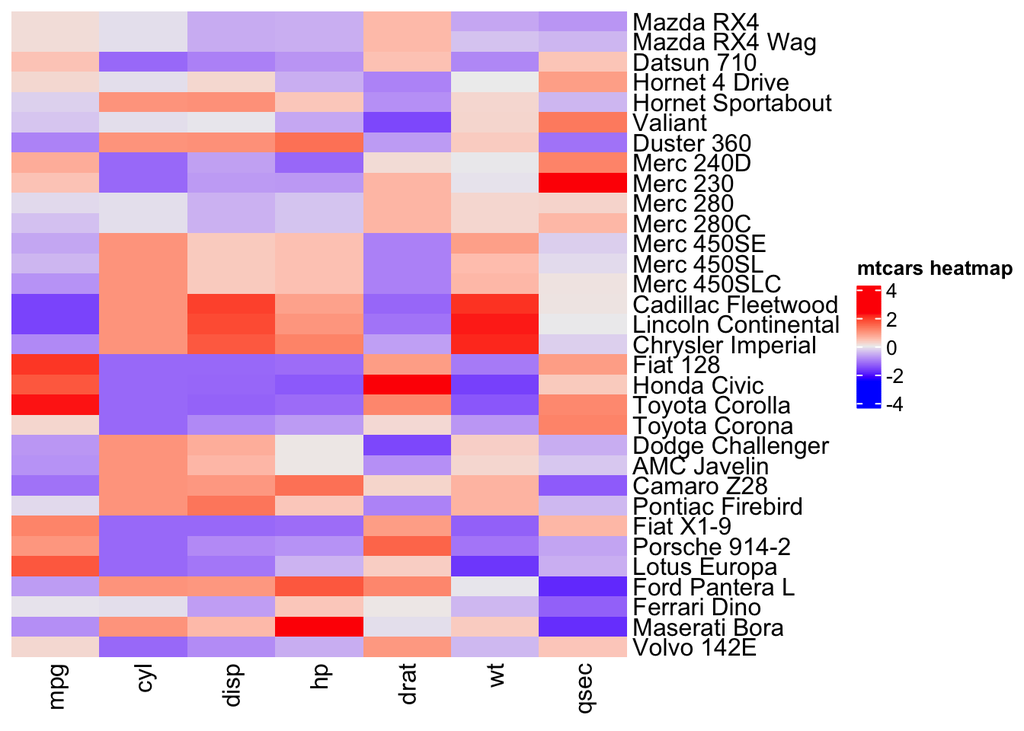

```r
Heatmap(data.scale, name = "mtcars heatmap",
        cluster_rows=FALSE , cluster_columns = FALSE)
```

Default clustering on rows

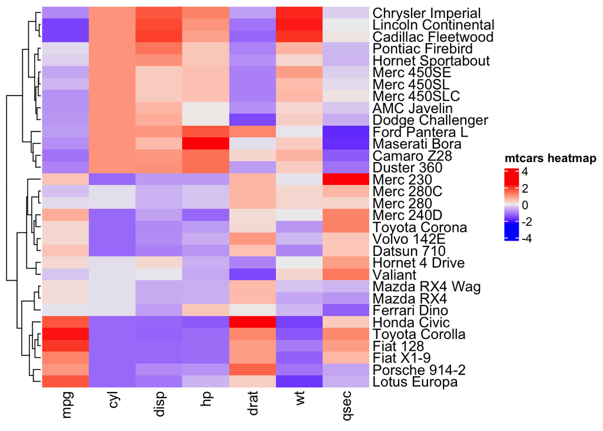

```r
Heatmap(data.scale, name = "mtcars heatmap",
        cluster_columns = FALSE)
```

Default clustering on rows and columns

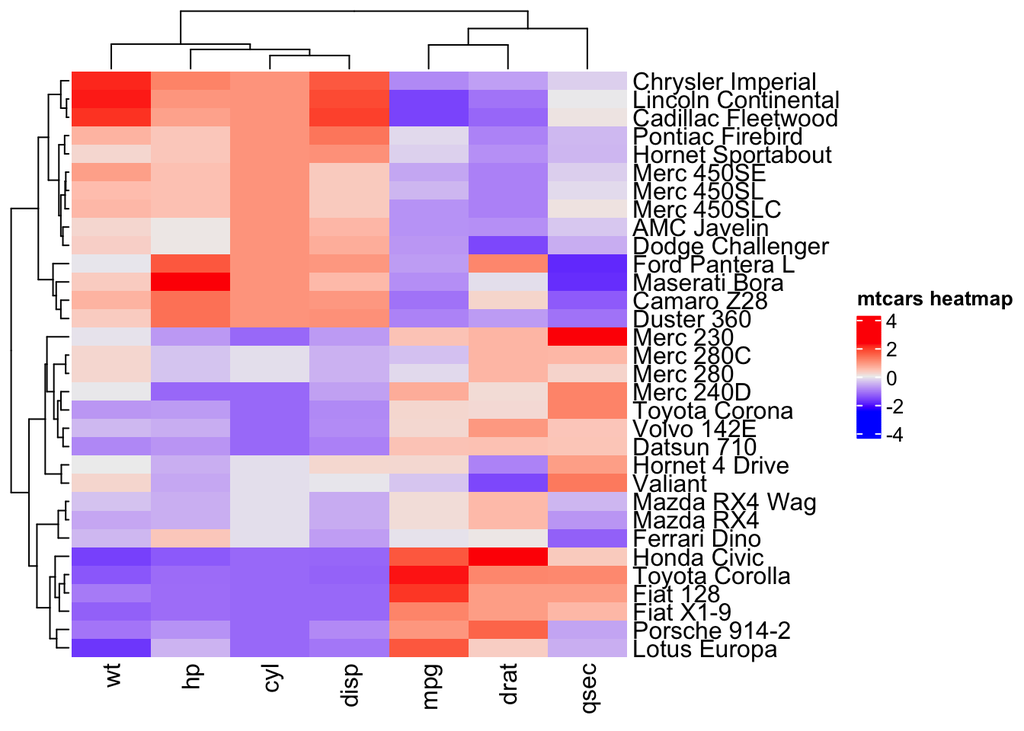

```r
Heatmap(data.scale, name = "mtcars heatmap")
```

Clustering using uncentered correlation and average linkage - declare a function for uncentered distance using cosange

```r
#cosangle function
uncenter.dist<-function(m) {
  as.dist(as.matrix(distancematrix(m, d="cosangle")))
}
```

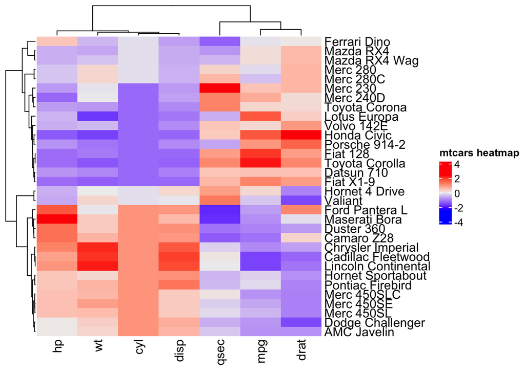

```r
row.clus<-hclust(uncenter.dist(data.scale), method = "ave")
col.clus<-hclust(uncenter.dist(t(data.scale)), method = "ave")

Heatmap(data.scale, name = "mtcars heatmap",
        cluster_rows=row.clus, cluster_columns=col.clus)
```

HCA Heatmap Annotations of 0/1 Dichotomous Variables

Following Bowers(2010) for format, here we will use two 0/1 dichotomous variables, if the car is a manual=1 or automatic=0, and if the engine block layout for the cylinders is inline=1 or in a V pattern=0

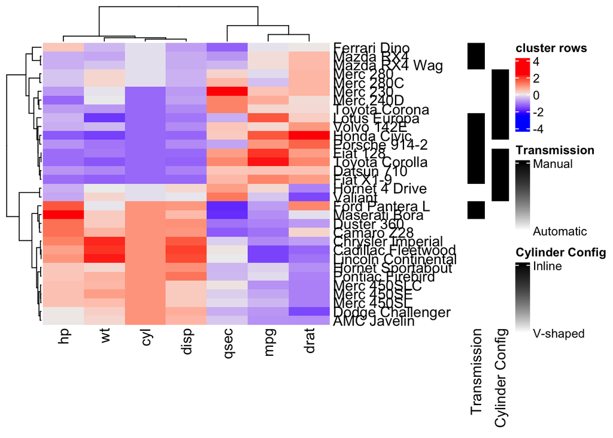

```r
ht_inline<-Heatmap(mtcars[, c(8)], name = "Cylinder Config",
                   col = colorRamp2(c(0,1),c("white", "black")),
                   heatmap_legend_param = list(at = c(0,1),
                         labels = c("V-shaped", "Inline")),
                   width = unit(0.5,"cm"))

ht_manual<-Heatmap(mtcars[, c(9)], name = "Transmission",
                   col = colorRamp2(c(0,1),c("white", "black")),
                   heatmap_legend_param = list(at = c(0,1),
                         labels = c("Automatic", "Manual")),
                   width = unit(0.5,"cm"))

ht_main = Heatmap(data.scale, name = "cluster rows",
                  cluster_rows=row.clus, cluster_columns = col.clus)

draw(ht_main+ht_manual+ht_inline, auto_adjust = FALSE)
```

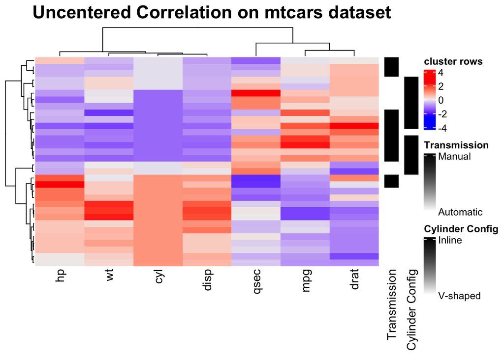

```r
ht_list = ht_main+ht_manual+ht_inline

draw(ht_list,
     column_title = "Uncentered Correlation on mtcars dataset",
     column_title_gp = gpar(fontsize =18, fontface = "bold"))
```

## 2. mtrcars 3 different iterations

Select at least three different options/alternatives from ComplexHeatmap’s first three chapters, and apply them to the mtcars dataset. For example, such as using different clustering algorithms (k-means, etc.), separation of heatmaps, stacking, different ways to annotate (columns and rows and different graphing options beyond black/white blocks), etc. Please provide some text in your markdown discussing what options/alternatives you selected, why this was interesting, and any challenges you experienced with running the visualizations. Provide a few sentences to interpret each new heatmap visualization.

Bowers (2022) Uncentered correlations heatmap of mtcars dataset

```r
data<-mtcars[, c(1:7)]



str (data)
```

```
## 'data.frame':    32 obs. of  7 variables:
##  $ mpg : num  21 21 22.8 21.4 18.7 18.1 14.3 24.4 22.8 19.2 ...
##  $ cyl : num  6 6 4 6 8 6 8 4 4 6 ...
##  $ disp: num  160 160 108 258 360 ...
##  $ hp  : num  110 110 93 110 175 105 245 62 95 123 ...
##  $ drat: num  3.9 3.9 3.85 3.08 3.15 2.76 3.21 3.69 3.92 3.92 ...
##  $ wt  : num  2.62 2.88 2.32 3.21 3.44 ...
##  $ qsec: num  16.5 17 18.6 19.4 17 ...
```

```r
cars<-scale(data)
head(cars)
```

```
##                          mpg        cyl        disp         hp       drat
## Mazda RX4          0.1508848 -0.1049878 -0.57061982 -0.5350928  0.5675137
## Mazda RX4 Wag      0.1508848 -0.1049878 -0.57061982 -0.5350928  0.5675137
## Datsun 710         0.4495434 -1.2248578 -0.99018209 -0.7830405  0.4739996
## Hornet 4 Drive     0.2172534 -0.1049878  0.22009369 -0.5350928 -0.9661175
## Hornet Sportabout -0.2307345  1.0148821  1.04308123  0.4129422 -0.8351978
## Valiant           -0.3302874 -0.1049878 -0.04616698 -0.6080186 -1.5646078
##                             wt       qsec
## Mazda RX4         -0.610399567 -0.7771651
## Mazda RX4 Wag     -0.349785269 -0.4637808
## Datsun 710        -0.917004624  0.4260068
## Hornet 4 Drive    -0.002299538  0.8904872
## Hornet Sportabout  0.227654255 -0.4637808
## Valiant            0.248094592  1.3269868
```

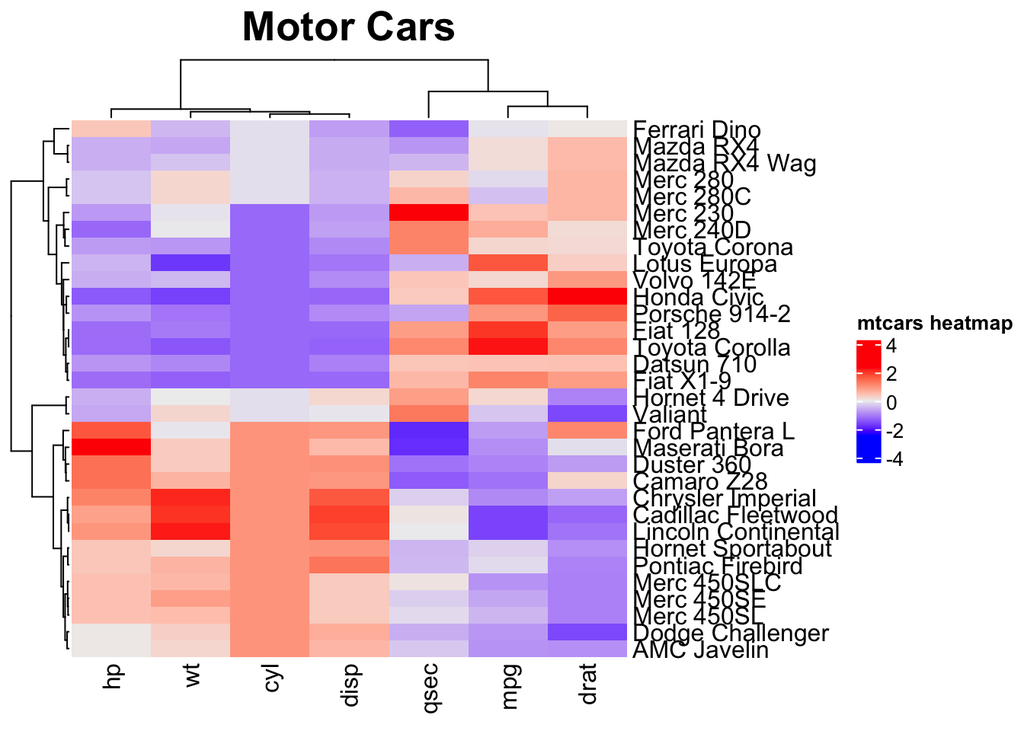

```r
uncenter.dist<-function(m) {
  as.dist(as.matrix(distancematrix(m, d="cosangle")))
}

row.clus<-hclust(uncenter.dist(cars), method = "ave")
col.clus<-hclust(uncenter.dist(t(cars)), method = "ave")



htmain = Heatmap(cars, name = "mtcars heatmap",
        cluster_rows=row.clus, cluster_columns=col.clus,
        column_title = "Motor Cars",
        column_title_gp = gpar(fontsize = 20, fontface = "bold"))

draw(htmain)
```

Motorcars Alphabetically

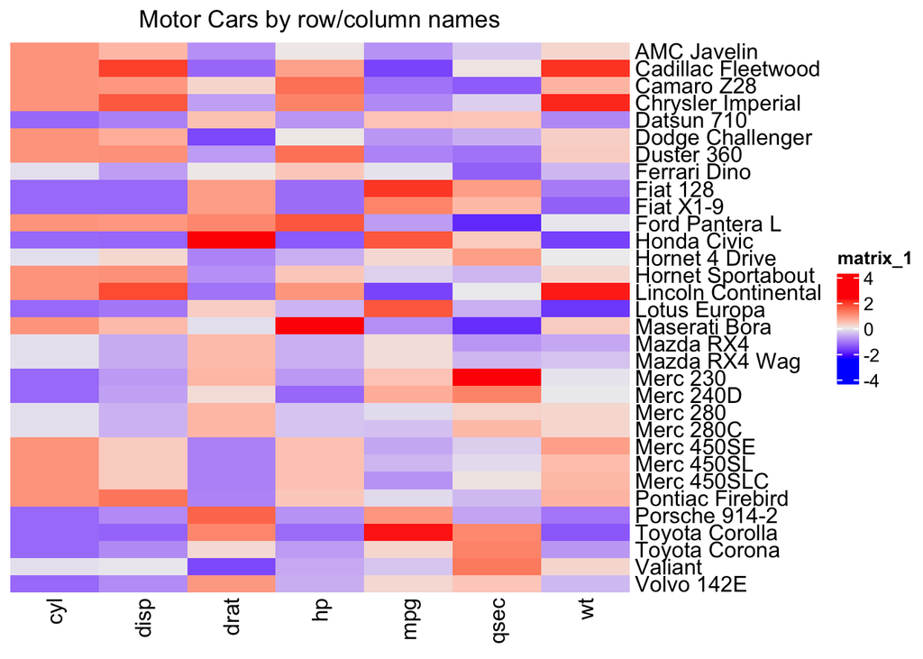

```r
Heatmap(cars,
        row_order = sort(rownames(cars)),
        column_order = sort(colnames(cars)),
        column_title = "Motor Cars by row/column names")
```

##2. Heatmap Annotations

Base HeatMap

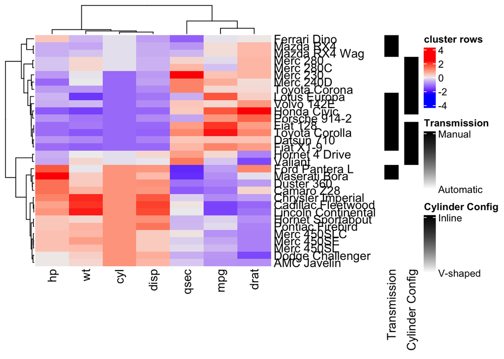

```r
ht_inline<-Heatmap(mtcars[, c(8)], name = "Cylinder Config",
                   col = colorRamp2(c(0,1),c("white", "black")),
                   heatmap_legend_param = list(at = c(0,1),
                         labels = c("V-shaped", "Inline")),
                   width = unit(0.5,"cm"))

ht_manual<-Heatmap(mtcars[, c(9)], name = "Transmission",
                   col = colorRamp2(c(0,1),c("white", "black")),
                   heatmap_legend_param = list(at = c(0,1),
                         labels = c("Automatic", "Manual")),
                   width = unit(0.5,"cm"))


ht_cyl <- Heatmap(mtcars[,c(2)], name = "Cylinders",
                  col = colorRamp2(c(0,1),c("white", "black")),
                   heatmap_legend_param = list(at = c(0,1),
                         labels = c("Automatic", "Manual")),
                   width = unit(0.5,"cm"))

ht_main = Heatmap(data.scale, name = "cluster rows",
                  cluster_rows=row.clus, cluster_columns = col.clus)

draw(ht_main+ht_manual+ht_inline, auto_adjust = FALSE)
```

```r
ht_list = ht_main+ht_manual+ht_inline
```

###Iteration 1

The original plot was resized in order to make the plot more visually appealing. The row names were also adjusted so that each row could be identified. Additionally a row annotation was added to create a column of points alongside the main heatmap, with each point representing the horsepower. This visual representation of horsepower is interesting because it allows viewers at a glance to see how horsepower varies across cars without needing an additional color scale or label. Figuring out what sizing was most visually appealing was not challenging however it did take some time to play with the unlimited options. The row annotation when copied into the submitting group member’s markdown needed to be adjusted for it to be ran without error.

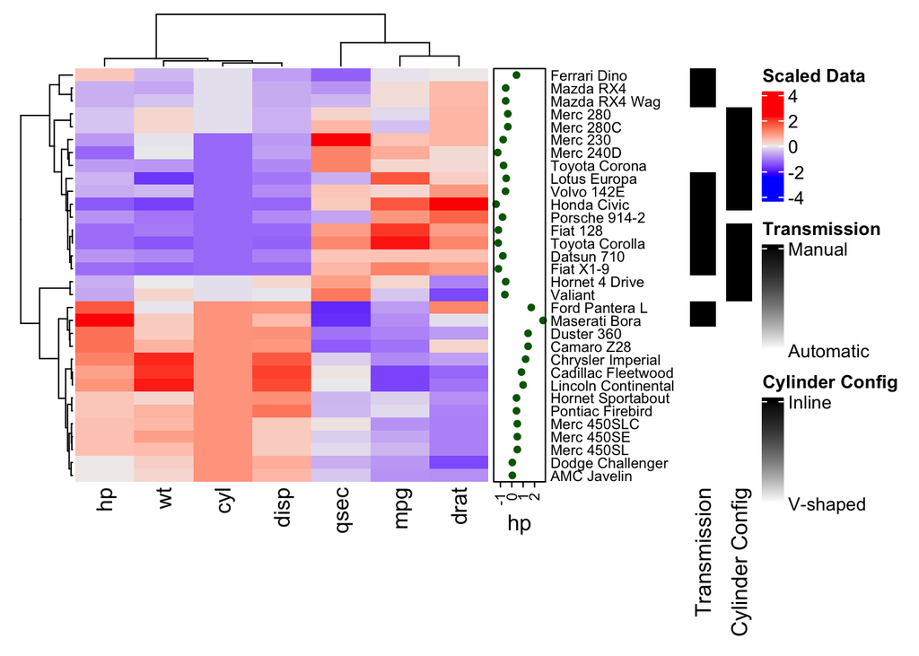

```r
# extract dichotomous variables from data set
ht_inline<-Heatmap(mtcars[, c(8)], name = "Cylinder Config",
                   col = colorRamp2(c(0,1),c("white", "black")),
                   heatmap_legend_param = list(at = c(0,1),
                         labels = c("V-shaped", "Inline")),
                   width = unit(0.5,"cm"))

ht_manual<-Heatmap(mtcars[, c(9)], name = "Transmission",
                   col = colorRamp2(c(0,1),c("white", "black")),
                   heatmap_legend_param = list(at = c(0,1),
                         labels = c("Automatic", "Manual")),
                   width = unit(0.5,"cm"))

row_annot <- rowAnnotation(hp = anno_points(cars[, "hp"], gp = gpar(col = "darkgreen")),
                           width = unit(1, "cm"))

# Main heatmap with clustering
ht_main <- Heatmap(data.scale,
                   name = "Scaled Data",
                   cluster_rows = row.clus,
                   cluster_columns = col.clus,
                   right_annotation = row_annot,
                   width = unit(8, "cm"), height = unit(8, "cm"),
                   row_names_gp = gpar(fontsize = 8))

# Draw all elements together
draw(ht_main + ht_manual + ht_inline, auto_adjust = FALSE)
```

###Iteration 2

Joyplots or ridgeline plots visualzie the distribution of variables, the incorporation of a ridgeline plot as the column headers allows the audience to more readily perceive the distribution of the variables. Plotting the distribution of the variables you can see the peaks of the variables, including display, weight and rear axle ratio. The heatmap provides a landscape perspective of the dataset and allows for clustering similar cars together, providing the ridgeline plots allows for another insight into one particular variable.

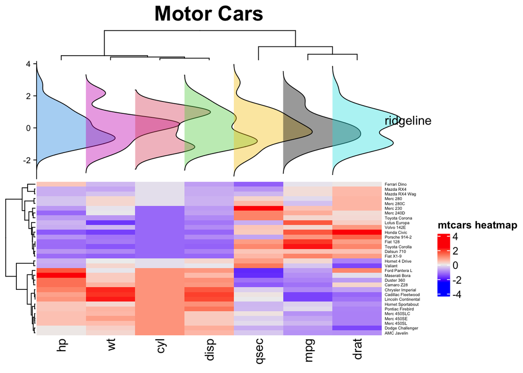

```r
lt = apply(cars, 2, function(x) data.frame(density(x)[c("x","y")]))

ha = HeatmapAnnotation(ridgeline = anno_joyplot(lt, width = unit(2,"cm"), gp=gpar(fill=1:10, transcparency =.75)))

Heatmap(cars, name = "mtcars heatmap",
        cluster_rows=row.clus, cluster_columns=col.clus,
          row_names_gp = gpar(fontsize = 4),
       top_annotation =ha,
        column_title = "Motor Cars",
        column_title_gp = gpar(fontsize = 20, fontface = "bold"))
```

```r
#cosine is uncentered correlation
```

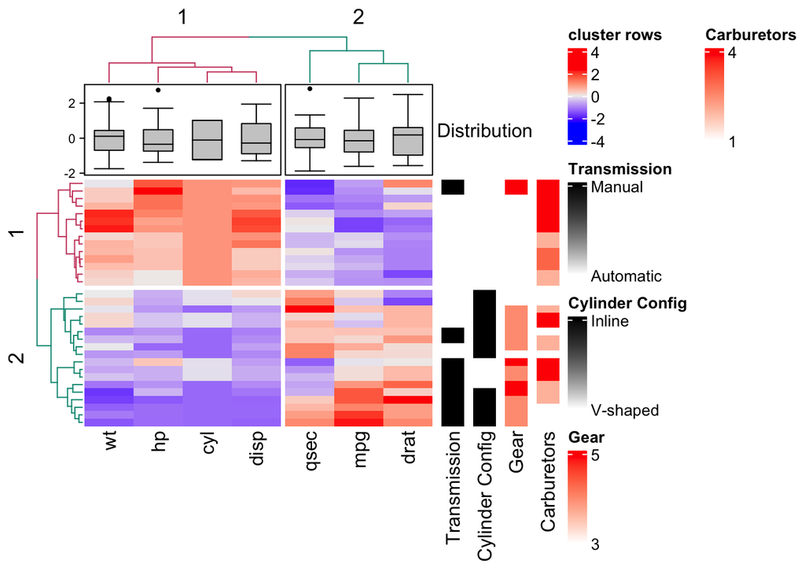

```r
ht_inline<-Heatmap(mtcars[, c(8)], name = "Cylinder Config",
                   col = colorRamp2(c(0,1),c("white", "black")),
                   heatmap_legend_param = list(at = c(0,1),
                         labels = c("V-shaped", "Inline")),
                   width = unit(0.5,"cm"))

ht_manual<-Heatmap(mtcars[, c(9)], name = "Transmission",
                   col = colorRamp2(c(0,1),c("white", "black")),
                   heatmap_legend_param = list(at = c(0,1),
                         labels = c("Automatic", "Manual")),
                   width = unit(0.5,"cm"))

ht_gear<-Heatmap(mtcars[, c(10)], name = "Gear",
                   col = colorRamp2(c(3,5),c("white", "red")),
                   heatmap_legend_param = list(at = c(3,5),
                         labels = c("3","5")),
                   width = unit(0.5,"cm"))

ht_carb<-Heatmap(mtcars[, c(11)], name = "Carburetors",
                   col = colorRamp2(c(1,4),c("white", "red")),
                   heatmap_legend_param = list(at = c(1,4),
                         labels = c("1", "4")),
                   width = unit(0.5,"cm"))

library(dendextend)
row_dend = as.dendrogram(hclust(dist(data.scale)))
row_dend = color_branches(row_dend, k = 2) # color_branches() returns a dendrogram object
col_dend = as.dendrogram(hclust(dist(t(data.scale))))
col_dend = color_branches(col_dend, k = 2) # color_branches() returns a dendrogram object

ht_main = Heatmap(cars, name = "cluster rows",
                  cluster_rows=row_dend, cluster_columns = col_dend, row_split=2, column_split=2,
                    top_annotation = HeatmapAnnotation(Distribution = anno_boxplot(data.scale)))

draw(ht_main+ht_manual+ht_inline+ht_gear+ht_carb)
```

## Research Proposal

### Purpose of this study

The purpose of this study is to use a cluster analysis heatmap to create a descriptive analysis of summer programming types attended by Asian and Hispanic students between 1st and 2nd grade. By examining the kinds of ‘outside-of-school’ activities these students engage in outside of the traditional classroom, this study seeks to uncover participation patterns that could possibly highlight disparities in access to summer programming opportunities. With the field of education’s current emphasis on closing equity gaps, this study will explore whether Asian and Hispanic students have distinct patterns in summer programming participation.

### Research literature on this topic

There is promising evidence in the literature that summer enrichment programs can lead to improved academic outcomes and enhanced social skills among low-income students (Augustine et al., 2016). These programs can also enhance students’ critical thinking and professional skills, as evidenced by research indicating that hands-on experiences during summer learning can positively influence students’ academic trajectories (Hernandez-Matias et al., 2019).

However, disparities in access and participation in these enrichment activities are prevalent across various demographic groups. McCombs et al. highlight that summer programs can mitigate learning loss and promote positive outcomes, particularly for low-income students who lack access to enriching activities during this period (McCombs et al., 2020). Atterberry and McEachin further emphasize the role of summer in understanding achievement disparities, noting that students from lower socioeconomic backgrounds experience greater learning loss during the summer compared to their more affluent peers (Atteberry & McEachin, 2020). This phenomenon is often referred to as the “summer slide”, where students lose academic skills over the break, a trend that disproportionately affects those already at a disadvantage (Dresden, 2019). The evidence suggests that targeted summer interventions can help bridge these gaps, yet participation remains uneven across demographic lines (Davies et al., 2022). The impact of summer programming on academic achievement is further illustrated by Kuhfield et al., who analyzed racial and ethnic disparities in learning and found that achievement gaps can shrink during summer months when students engage in structured activities (Kuhfeld et al., 2020).

Citations

Atteberry, A. and McEachin, A. (2020). School’s out: the role of summers in understanding achievement disparities. American Educational Research Journal, 58(2), 239-282. https://doi.org/10.3102/0002831220937285

Augustine, C., McCombs, J., Pane, J., Schwartz, H., Schweig, J., McEachin, A., … & Siler-Evans, K. (2016). Learning from summer: effects of voluntary summer learning programs on low-income urban youth.. https://doi.org/10.7249/rr1557

Davies, S., Aurini, J., & Hillier, C. (2022). Reproducing or reducing inequality? the case of summer learning programs. Canadian Journal of Education / Revue Canadienne De L Éducation. https://doi.org/10.53967/cje-rce.5311

Hernández-Matias, L., Pérez-Donato, L., Román, P., Laureano-Torres, F., Calzada-Jorge, N., Mendoza, S., … & Borrero, M. (2019). An exploratory study comparing students’ science identity perceptions derived from a hands‐on research and nonresearch‐based summer learning experience. Biochemistry and Molecular Biology Education, 48(2), 134-142. https://doi.org/10.1002/bmb.21314

McCombs, J., Augustine, C., Pane, J., & Schweig, J. (2020). Every summer counts: a longitudinal analysis of outcomes from the national summer learning project.. https://doi.org/10.7249/rr3201

### Why use a cluster analysis heatmap?

Using a cluster analysis heatmap for this study will allow for visual groupings of participation types based on observed similarities and differences, capturing the diversity within and across student groups. Cluster analysis heatmaps are well-suited for descriptive analysis as it may reveal patterns that might otherwise go unnoticed in traditional tabular analysis. This approach will enable us to visually distinguish patterns of participation for Asian and Hispanic students, potentially identifying clusters based on demographics, socio-economic characteristics, and participation in specific program types. ### Research Questions What types of summer programming do Asian and Hispanic students participate in? How do demographic and socio-economic factors influence participation patterns in summer programs? To what extent do participation patterns represent academic outcomes the following school year? ### Data Source This study will utilize the ECLS-K:2011 (Early Childhood Longitudinal Study, Kindergarten Class of 2010-11) dataset from the National Center for Education Statistics (NCES). This public-use data set contains detailed information on students from kindergarten through fifth grade including demographics, family background, and educational outcomes. This dataset also includes responses from parents about children’s participation in summer activities, making it well-suited for this analysis. Key variables for clustering include summer programming types, demographics (such as Age, ethnicity, and language spoken at home), socio-economic factors (such as family income, SES, and parental occupation prestige scores), and behavioral and educational outcomes for the Fall semester after the summer. ### Clustering Approach and Generalized Equation For this study, agglomerative hierarchical clustering will be used, applying an uncensored correlation distance measure. Agglomerative clustering will start by treating each student as an individual cluster and gradually merge the clusters based on similarity until an optimal number of clusters is achieved. The uncentered correlation distance will be used to measure the similarity, the equation for this distance measure is represented below: The distance measure of uncentered correlation is represented below (Bowers, 2010, p.18)

$$r(x_i, y_i) = \frac{1}{n} \sum_{i=1}^n
\left( \frac{x_i}{\sigma_{x}^{(0)}} \right) \left(
\frac{y_i}{\sigma_{y}^{(0)}} \right)$$
where
$$\sigma_x^{(0)}= \sqrt{ \frac{1}{n} \sum_{i=1}^n
\left( x_i \right) ^2}$$
$$\sigma_y^{(0)}= \sqrt{ \frac{1}{n} \sum_{i=1}^n
\left( y_i \right) ^2}$$

The average distance between the total number of cases in both clusters, nAnB, between the total number of cases in cluster A, nA, and the total number of cases in cluster B, nB, is then used to determine the distance between any two clusters, A and B (Bowers, 2010, p.18). This is represented by:

$$D(A,B)=\frac{1}{n_An_B} \sum_{i=1}^{n_A}
\sum_{i=1}^{n_B} r(x_i,y_i)$$

Bowers, A. J., (2010) “Analyzing the longitudinal K-12 grading histories of entire cohorts of students: Grades, data driven decision making, dropping out and hierarchical cluster analysis”, Practical Assessment, Research, and Evaluation 15(1): 7. doi: https://doi.org/10.7275/r4zq-9c31 ### Hypothesis It hypothesized that Asian students may participate more frequently in academic and music programs than Hispanic students. Additionally, students from higher SES backgrounds may show higher participation rates across program types due to greater resource availability. ### Implications for this Research By providing a clearer picture of summer program engagement, this study can inform those in decision making positions to decrease opportunity and access gaps to summer programming. Ultimately, ever so slightly enhance educational equity across socio-economic and ethnic lines.

## Stretch Goal

```r
# Get the Data



# Either ISO-8601 date or year/week works!


tuesdata <- tidytuesdayR::tt_load(2021, week = 38)
```

```
## ---- Compiling #TidyTuesday Information for 2021-09-14 ----
## --- There are 2 files available ---
##
##
## ── Downloading files ───────────────────────────────────────────────────────────
##
##   1 of 2: "billboard.csv"
##   2 of 2: "audio_features.csv"
```

```r
audio_features <- tuesdata$audio_features
```

audio_features.csv

Variables for body of the heatmap acousticness key liveness speechiness tempo danceability valence energy loudness

dichotmous

Explicit (spotify_track_explicit) Mode

```r
library(dplyr)
str(audio_features)
```

```
## spc_tbl_ [29,503 × 22] (S3: spec_tbl_df/tbl_df/tbl/data.frame)
##  $ song_id                  : chr [1:29503] "-twistin'-White Silver SandsBill Black's Combo" "¿Dònde Està Santa Claus? (Where Is Santa Claus?)Augie Rios" "......And Roses And RosesAndy Williams" "...And Then There Were DrumsSandy Nelson" ...
##  $ performer                : chr [1:29503] "Bill Black's Combo" "Augie Rios" "Andy Williams" "Sandy Nelson" ...
##  $ song                     : chr [1:29503] "-twistin'-White Silver Sands" "¿Dònde Està Santa Claus? (Where Is Santa Claus?)" "......And Roses And Roses" "...And Then There Were Drums" ...
##  $ spotify_genre            : chr [1:29503] "[]" "['novelty']" "['adult standards', 'brill building pop', 'easy listening', 'mellow gold']" "['rock-and-roll', 'space age pop', 'surf music']" ...
##  $ spotify_track_id         : chr [1:29503] NA NA "3tvqPPpXyIgKrm4PR9HCf0" "1fHHq3qHU8wpRKHzhojZ4a" ...
##  $ spotify_track_preview_url: chr [1:29503] NA NA "https://p.scdn.co/mp3-preview/cef4883cfd1e0e5312be7ccce98176cff46d7879?cid=b8d3901151d34489a160e3cf0ab1fa94" NA ...
##  $ spotify_track_duration_ms: num [1:29503] NA NA 166106 172066 211066 ...
##  $ spotify_track_explicit   : logi [1:29503] NA NA FALSE FALSE FALSE FALSE ...
##  $ spotify_track_album      : chr [1:29503] NA NA "The Essential Andy Williams" "Compelling Percussion" ...
##  $ danceability             : num [1:29503] NA NA 0.154 0.588 0.759 0.613 NA 0.647 NA NA ...
##  $ energy                   : num [1:29503] NA NA 0.185 0.672 0.699 0.764 NA 0.686 NA NA ...
##  $ key                      : num [1:29503] NA NA 5 11 0 2 NA 2 NA NA ...
##  $ loudness                 : num [1:29503] NA NA -14.06 -17.28 -5.75 ...
##  $ mode                     : num [1:29503] NA NA 1 0 0 1 NA 0 NA NA ...
##  $ speechiness              : num [1:29503] NA NA 0.0315 0.0361 0.0307 0.136 NA 0.0274 NA NA ...
##  $ acousticness             : num [1:29503] NA NA 0.911 0.00256 0.202 0.0527 NA 0.432 NA NA ...
##  $ instrumentalness         : num [1:29503] NA NA 2.67e-04 7.45e-01 1.31e-04 0.00 NA 6.19e-06 NA NA ...
##  $ liveness                 : num [1:29503] NA NA 0.112 0.145 0.443 0.197 NA 0.133 NA NA ...
##  $ valence                  : num [1:29503] NA NA 0.15 0.801 0.907 0.417 NA 0.952 NA NA ...
##  $ tempo                    : num [1:29503] NA NA 84 122 93 ...
##  $ time_signature           : num [1:29503] NA NA 4 4 4 4 NA 4 NA NA ...
##  $ spotify_track_popularity : num [1:29503] NA NA 38 11 77 73 61 40 NA NA ...
##  - attr(*, "spec")=
##   .. cols(
##   ..   song_id = col_character(),
##   ..   performer = col_character(),
##   ..   song = col_character(),
##   ..   spotify_genre = col_character(),
##   ..   spotify_track_id = col_character(),
##   ..   spotify_track_preview_url = col_character(),
##   ..   spotify_track_duration_ms = col_double(),
##   ..   spotify_track_explicit = col_logical(),
##   ..   spotify_track_album = col_character(),
##   ..   danceability = col_double(),
##   ..   energy = col_double(),
##   ..   key = col_double(),
##   ..   loudness = col_double(),
##   ..   mode = col_double(),
##   ..   speechiness = col_double(),
##   ..   acousticness = col_double(),
##   ..   instrumentalness = col_double(),
##   ..   liveness = col_double(),
##   ..   valence = col_double(),
##   ..   tempo = col_double(),
##   ..   time_signature = col_double(),
##   ..   spotify_track_popularity = col_double()
##   .. )
##  - attr(*, "problems")=<externalptr>
```

```r
colnames(audio_features)
```

```
##  [1] "song_id"                   "performer"
##  [3] "song"                      "spotify_genre"
##  [5] "spotify_track_id"          "spotify_track_preview_url"
##  [7] "spotify_track_duration_ms" "spotify_track_explicit"
##  [9] "spotify_track_album"       "danceability"
## [11] "energy"                    "key"
## [13] "loudness"                  "mode"
## [15] "speechiness"               "acousticness"
## [17] "instrumentalness"          "liveness"
## [19] "valence"                   "tempo"
## [21] "time_signature"            "spotify_track_popularity"
```

```r
audio_features <- as.data.frame(audio_features)



audio_features <- filter(audio_features, spotify_track_popularity > 90)
```

### Clean Data

```r
library(tidyverse)
library(dplyr)





songs_df <- as.data.frame(audio_features)




#remove any duplicates

songs_df <- songs_df |>
  distinct(song_id, .keep_all = TRUE)
#merge performer and song name to one variable



audio_features$full_song <- paste(audio_features$performer , audio_features$song, sep = " ")
#reassign song names as row names

rownames(songs_df) <- songs_df$full_song
```

```r
songs <- songs_df[c(10:20)]

str(songs)
```

```
## 'data.frame':    61 obs. of  11 variables:
##  $ danceability    : num  0.778 0.734 0.676 0.335 0.778 0.701 0.474 0.513 0.769 0.61 ...
##  $ energy          : num  0.317 0.836 0.771 0.625 0.695 0.425 0.631 0.796 0.787 0.624 ...
##  $ key             : num  1 10 8 7 4 7 5 1 11 2 ...
##  $ loudness        : num  -10.73 -4.8 -3.67 -7.46 -6.87 ...
##  $ mode            : num  0 0 1 1 0 1 0 1 1 1 ...
##  $ speechiness     : num  0.334 0.0735 0.0483 0.0386 0.0913 0.375 0.343 0.0629 0.367 0.309 ...
##  $ acousticness    : num  0.592 0.017 0.0237 0.164 0.175 0.328 0.0687 0.00147 0.189 0.6 ...
##  $ instrumentalness: num  0.00 1.64e-05 7.00e-06 0.00 0.00 1.30e-01 0.00 2.09e-04 0.00 2.12e-06 ...
##  $ liveness        : num  0.0881 0.179 0.102 0.0708 0.15 0.1 0.132 0.0938 0.129 0.243 ...
##  $ valence         : num  0.327 0.623 0.569 0.346 0.472 0.562 0.425 0.345 0.836 0.244 ...
##  $ tempo           : num  140 80 99 150 150 ...
```

```r
songs <- songs[-(5)]

head(songs)
```

```
##   danceability energy key loudness speechiness acousticness instrumentalness
## 1        0.778  0.317   1  -10.732      0.3340       0.5920         0.00e+00
## 2        0.734  0.836  10   -4.803      0.0735       0.0170         1.64e-05
## 3        0.676  0.771   8   -3.675      0.0483       0.0237         7.00e-06
## 4        0.335  0.625   7   -7.462      0.0386       0.1640         0.00e+00
## 5        0.778  0.695   4   -6.865      0.0913       0.1750         0.00e+00
## 6        0.701  0.425   7  -10.965      0.3750       0.3280         1.30e-01
##   liveness valence   tempo
## 1   0.0881   0.327 140.048
## 2   0.1790   0.623  80.002
## 3   0.1020   0.569  99.048
## 4   0.0708   0.346 150.277
## 5   0.1500   0.472 149.996
## 6   0.1000   0.562 135.128
```

```r
#removing instrumentaliness
songs <- songs[-(7)]


colnames(songs)
```

```
## [1] "danceability" "energy"       "key"          "loudness"     "speechiness"
## [6] "acousticness" "liveness"     "valence"      "tempo"
```

```r
#scale the data

song_scale <- scale(songs)

head(song_scale)
```

```
##      danceability     energy        key     loudness speechiness acousticness
## [1,]    0.7750332 -1.5323317 -1.4866881 -1.523230933   2.3049912   0.94768676
## [2,]    0.4854746  1.6475378  1.2339511  0.821745904  -0.4136922  -1.02443387
## [3,]    0.1037837  1.2492882  0.6293646  1.267880813  -0.6766896  -1.00145438
## [4,]   -2.1402957  0.3547585  0.3270714 -0.229914310  -0.7779228  -0.52025695
## [5,]    0.7750332  0.7836426 -0.5798084  0.006204963  -0.2279242  -0.48252942
## [6,]    0.2683056 -0.8706247  0.3270714 -1.615384687   2.7328838   0.04222615
##         liveness     valence      tempo
## [1,] -0.63079072 -0.68221429  0.5103496
## [2,]  0.05276211  0.64902186 -1.3504359
## [3,] -0.52626504  0.40616121 -0.7602130
## [4,] -0.76088384 -0.59676332  0.8273395
## [5,] -0.16531305 -0.03008847  0.8186315
## [6,] -0.54130471  0.37467928  0.3578821
```

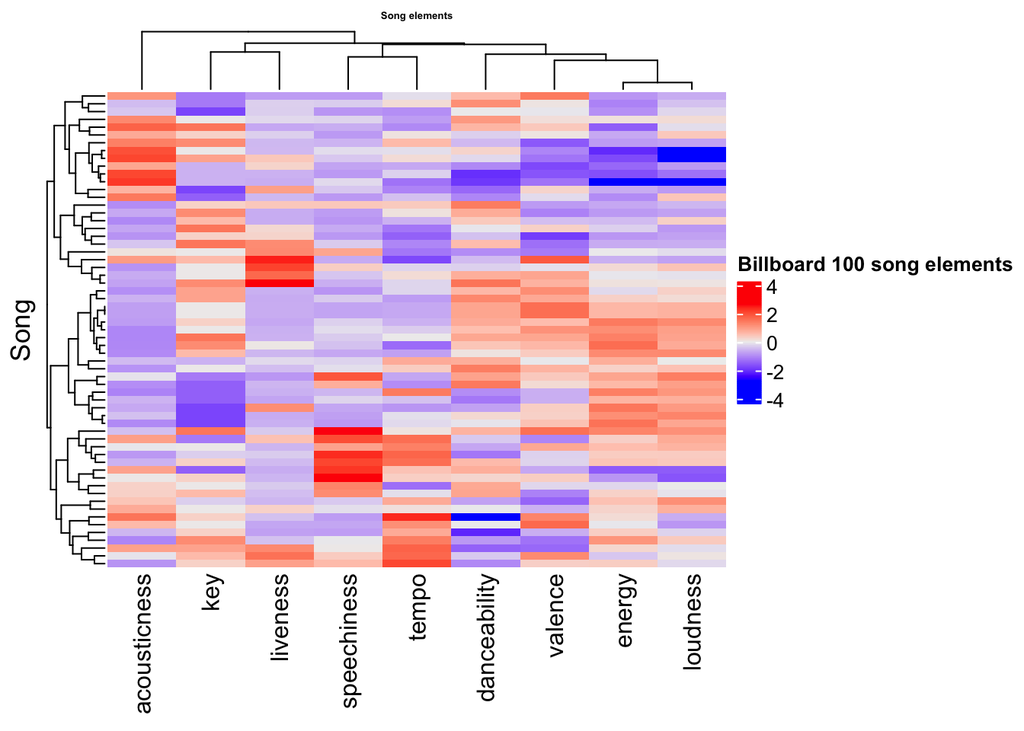

```r
uncenter.dist<-function(m) {
  as.dist(as.matrix(distancematrix(m, d="cosangle")))
}

row.clus<-hclust(uncenter.dist(song_scale), method = "ave")
col.clus<-hclust(uncenter.dist(t(song_scale)), method = "ave")



htmain = Heatmap(song_scale, name = "Billboard 100 song elements",
        cluster_rows=row.clus, cluster_columns=col.clus,
        column_title = "Song elements",
        column_title_gp = gpar(fontsize = 5, fontface = "bold"),
        row_title = "Song",
       row_names_gp = gpar(fontsize = 5))

draw(htmain)
```

```r
#annotation heatmaps

#remove any duplicates of audio_features


audio_features <- audio_features |>
  distinct(song_id, .keep_all = TRUE)


audio_features <- as.data.frame(audio_features)

#song and artist name column
audio_features$full_song <- paste(audio_features$performer , audio_features$song, sep = " ")
#reassign song names as row names

rownames(audio_features) <- audio_features$full_song





head(audio_features)
```

```
##                                                                                  song_id
## Ariana Grande 7 Rings                                               7 RingsAriana Grande
## Tainy, Anuel AA & Ozuna Adicto                             AdictoTainy, Anuel AA & Ozuna
## Harry Styles Adore You                                             Adore YouHarry Styles
## Mariah Carey All I Want For Christmas Is You All I Want For Christmas Is YouMariah Carey
## Masked Wolf Astronaut In The Ocean                     Astronaut In The OceanMasked Wolf
## Billie Eilish Bad Guy                                               Bad GuyBillie Eilish
##                                                            performer
## Ariana Grande 7 Rings                                  Ariana Grande
## Tainy, Anuel AA & Ozuna Adicto               Tainy, Anuel AA & Ozuna
## Harry Styles Adore You                                  Harry Styles
## Mariah Carey All I Want For Christmas Is You            Mariah Carey
## Masked Wolf Astronaut In The Ocean                       Masked Wolf
## Billie Eilish Bad Guy                                  Billie Eilish
##                                                                         song
## Ariana Grande 7 Rings                                                7 Rings
## Tainy, Anuel AA & Ozuna Adicto                                        Adicto
## Harry Styles Adore You                                             Adore You
## Mariah Carey All I Want For Christmas Is You All I Want For Christmas Is You
## Masked Wolf Astronaut In The Ocean                    Astronaut In The Ocean
## Billie Eilish Bad Guy                                                Bad Guy
##                                                                                  spotify_genre
## Ariana Grande 7 Rings                                    ['dance pop', 'pop', 'post-teen pop']
## Tainy, Anuel AA & Ozuna Adicto                                               ['pop reggaeton']
## Harry Styles Adore You                                   ['dance pop', 'pop', 'post-teen pop']
## Mariah Carey All I Want For Christmas Is You ['dance pop', 'pop', 'r&b', 'urban contemporary']
## Masked Wolf Astronaut In The Ocean                                      ['australian hip hop']
## Billie Eilish Bad Guy                                                    ['electropop', 'pop']
##                                                    spotify_track_id
## Ariana Grande 7 Rings                        6ocbgoVGwYJhOv1GgI9NsF
## Tainy, Anuel AA & Ozuna Adicto               3jbT1Y5MoPwEIpZndDDwVq
## Harry Styles Adore You                       1M4qEo4HE3PRaCOM7EXNJq
## Mariah Carey All I Want For Christmas Is You 0bYg9bo50gSsH3LtXe2SQn
## Masked Wolf Astronaut In The Ocean           3Ofmpyhv5UAQ70mENzB277
## Billie Eilish Bad Guy                        2Fxmhks0bxGSBdJ92vM42m
##                                                                                                                                spotify_track_preview_url
## Ariana Grande 7 Rings                                                                                                                               <NA>
## Tainy, Anuel AA & Ozuna Adicto                                                                                                                      <NA>
## Harry Styles Adore You                       https://p.scdn.co/mp3-preview/2dbeaa922270b3372d221f09c773a38696aed573?cid=b8d3901151d34489a160e3cf0ab1fa94
## Mariah Carey All I Want For Christmas Is You https://p.scdn.co/mp3-preview/ab4f06069148ef8510d8681164479601d4617bed?cid=b8d3901151d34489a160e3cf0ab1fa94
```

[output cut: 50 more lines]

```
## Billie Eilish Bad Guy                        135.128              4
##                                              spotify_track_popularity
## Ariana Grande 7 Rings                                              91
## Tainy, Anuel AA & Ozuna Adicto                                     91
## Harry Styles Adore You                                             91
## Mariah Carey All I Want For Christmas Is You                       95
## Masked Wolf Astronaut In The Ocean                                 96
## Billie Eilish Bad Guy                                              95
##                                                                                 full_song
## Ariana Grande 7 Rings                                               Ariana Grande 7 Rings
## Tainy, Anuel AA & Ozuna Adicto                             Tainy, Anuel AA & Ozuna Adicto
## Harry Styles Adore You                                             Harry Styles Adore You
## Mariah Carey All I Want For Christmas Is You Mariah Carey All I Want For Christmas Is You
## Masked Wolf Astronaut In The Ocean                     Masked Wolf Astronaut In The Ocean
## Billie Eilish Bad Guy                                               Billie Eilish Bad Guy
```

```r
colnames(audio_features)
```

```
##  [1] "song_id"                   "performer"
##  [3] "song"                      "spotify_genre"
##  [5] "spotify_track_id"          "spotify_track_preview_url"
##  [7] "spotify_track_duration_ms" "spotify_track_explicit"
##  [9] "spotify_track_album"       "danceability"
## [11] "energy"                    "key"
## [13] "loudness"                  "mode"
## [15] "speechiness"               "acousticness"
## [17] "instrumentalness"          "liveness"
## [19] "valence"                   "tempo"
## [21] "time_signature"            "spotify_track_popularity"
## [23] "full_song"
```

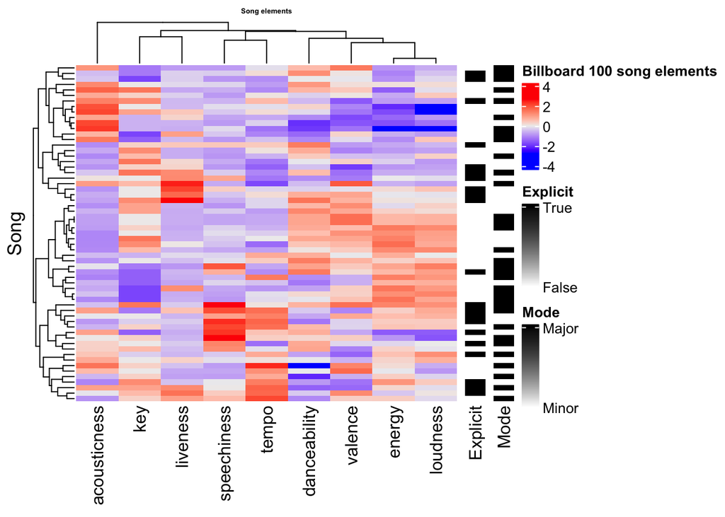

```r
ht_explicit<-Heatmap(audio_features[, c(8)], name = "Explicit",
                   col = colorRamp2(c(0,1),c("white", "black")),
                   heatmap_legend_param = list(at = c(0,1),
                         labels = c("False", "True")),
                   width = unit(0.5,"cm"))

ht_model<-Heatmap(audio_features[, c(14)], name = "Mode",
                   col = colorRamp2(c(0,1),c("white", "black")),
                   heatmap_legend_param = list(at = c(0,1),
                         labels = c("Minor", "Major")),
                   width = unit(0.5,"cm"))

draw(htmain + ht_explicit + ht_model, auto_adjust = FALSE)
```